# Insect Abundance Seasonal ARIMA

Isabella Escamilla

## Introduction

The goal of this analysis is to create a seasonal ARIMA model of the insect abundance data set. First, I will import the data and make any modifications necessary.

```r
dataloc <- './DataSource/data/InsectAbundanceBiomassData.csv'
data <- read.csv(dataloc)
summary(data)
```

```
##  DataSource_ID     Plot_ID       Stratum            MetricAB
##  Min.   :  63   Min.   :   1   Length:70955       Length:70955
##  1st Qu.:1263   1st Qu.: 375   Class :character   Class :character
##  Median :1444   Median : 904   Mode  :character   Mode  :character
##  Mean   :1231   Mean   : 917
##  3rd Qu.:1487   3rd Qu.:1426
##  Max.   :1527   Max.   :1872
##
##     Period               Year          Number
##  Length:70955       Min.   :1925   Min.   :      0
##  Class :character   1st Qu.:1995   1st Qu.:      4
##  Mode  :character   Median :2003   Median :     32
##                     Mean   :2001   Mean   :   1963
##                     3rd Qu.:2010   3rd Qu.:    188
##                     Max.   :2018   Max.   :5005000
##                                    NA's   :9955
```

There’s a lot of data from different sources, so we will choose one data source to examine for now to avoid inconsistencies. We will be look at the grasslands butterflies in Wisconsin.

```r
data2 <- data %>% filter(DataSource_ID == 1476)
head(data2, 15)
```

```
##    DataSource_ID Plot_ID Stratum  MetricAB Period Year    Number
## 1           1476     286     Air abundance      7 1997 170.98797
## 2           1476     286     Air abundance      8 1998  68.39519
## 3           1476     286     Air abundance      7 1999  66.38356
## 4           1476     286     Air abundance      8 1999  56.32545
## 5           1476     286     Air abundance      4 1999   0.00000
## 6           1476     286     Air abundance      4 2000   0.00000
## 7           1476     286     Air abundance      8 2000  22.12785
## 8           1476     286     Air abundance      5 2001   0.00000
## 9           1476     286     Air abundance      8 2001 414.39437
## 10          1476     286     Air abundance      9 2001 140.81362
## 11          1476     286     Air abundance      7 2001 213.23205
## 12          1476     286     Air abundance      8 2002 158.91823
## 13          1476     286     Air abundance      8 2002 179.03446
## 14          1476     286     Air abundance      5 2002  18.10461
## 15          1476     286     Air abundance      6 2002 160.92985
```

The months are inconsistent and won’t work as a time series object, so we will aggregate by year, dropping missing values first.

```r
data3 <- na.omit(data2)
agg_tbl <- data3 %>% group_by(Year) %>%
  summarise(mean_num=mean(Number),
            .groups = 'drop')
agg_tbl
```

```
## # A tibble: 31 × 2
##     Year mean_num
##    <int>    <dbl>
##  1  1987      4
##  2  1988     31.7
##  3  1989     56
##  4  1990    222.
##  5  1991    129.
##  6  1992    179.
##  7  1993    146.
##  8  1994    129.
##  9  1995     97.9
## 10  1996     91.1
## # … with 21 more rows
```

Now we can turn it into a time series.

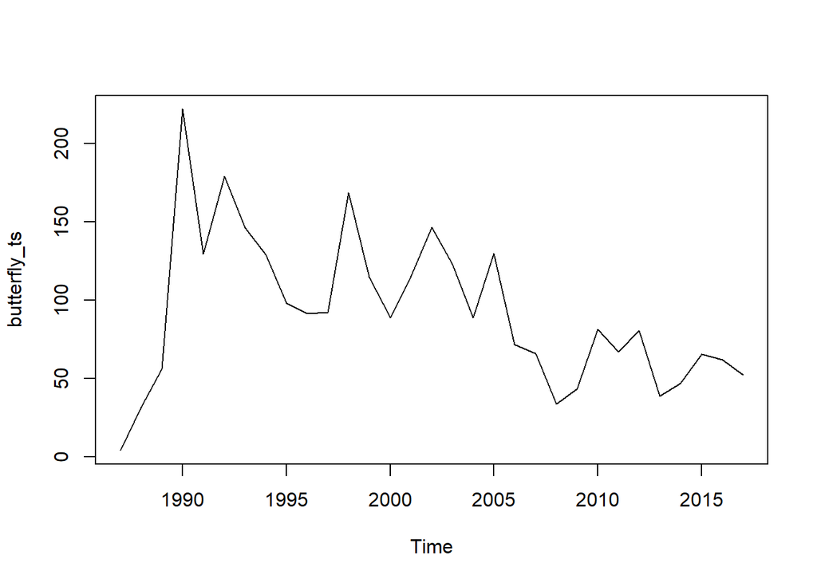

```r
butterfly_ts <- ts(agg_tbl$mean_num, start = 1987, end = 2017)
plot.ts(butterfly_ts)
```

We can see that the time series needs to be detrended.

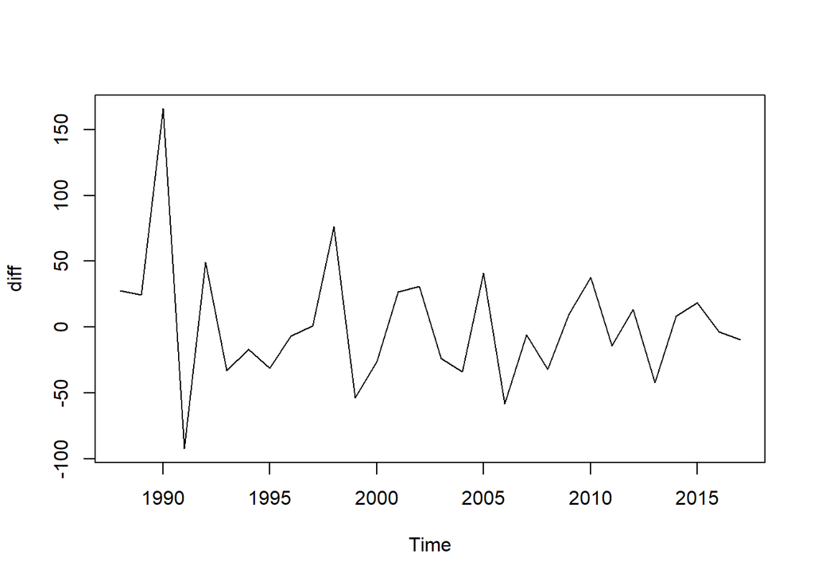

```r
diff <- diff(butterfly_ts)
plot.ts(diff)
```

Now we’ll look at the ACF.

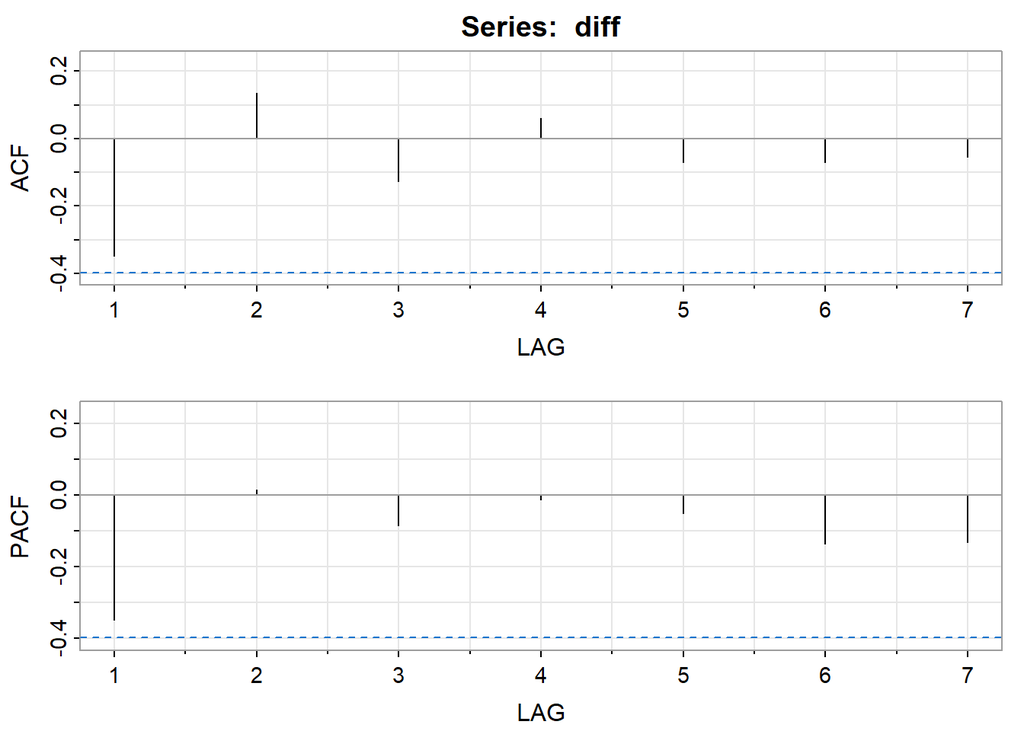

```
##       [,1] [,2]  [,3]  [,4]  [,5]  [,6]  [,7]
## ACF  -0.35 0.13 -0.13  0.06 -0.07 -0.07 -0.05
## PACF -0.35 0.02 -0.09 -0.01 -0.05 -0.14 -0.13
```

```r
acf2(diff)
```

Both the ACF and PACF cut off after lag 0, indicating that this likely follows a white noise model. This means that p and q are equal to zero, and d is equal to 1 since we took the first difference.

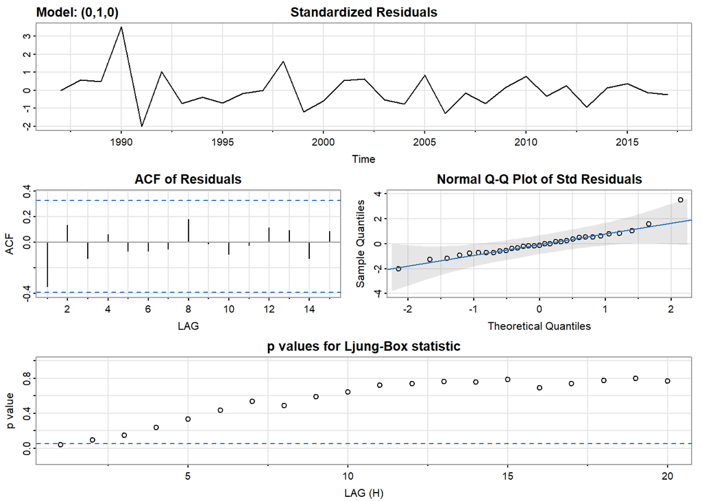

```
## $fit
##
## Call:
## arima(x = xdata, order = c(p, d, q), seasonal = list(order = c(P, D, Q), period = S),
##     xreg = constant, transform.pars = trans, fixed = fixed, optim.control = list(trace = trc,
##         REPORT = 1, reltol = tol))
##
## Coefficients:
##       constant
##         1.6078
## s.e.    8.5144
##
## sigma^2 estimated as 2175:  log likelihood = -157.84,  aic = 319.68
##
## $degrees_of_freedom
## [1] 29
##
## $ttable
##          Estimate     SE t.value p.value
## constant   1.6078 8.5144  0.1888  0.8515
##
## $AIC
## [1] 10.65592
##
## $AICc
## [1] 10.66068
##
## $BIC
## [1] 10.74933
```

```r
sarima(butterfly_ts, 0, 1, 0, 0, 0, 0)
```

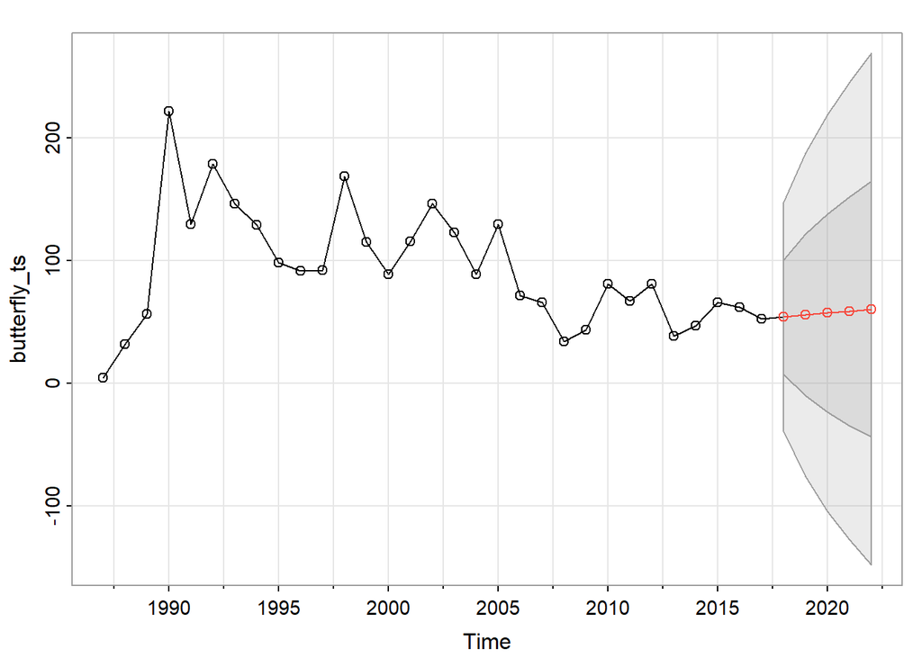

```
## $pred
## Time Series:
## Start = 2018
## End = 2022
## Frequency = 1
## [1] 53.84181 55.44961 57.05741 58.66521 60.27301
##
## $se
## Time Series:
## Start = 2018
## End = 2022
## Frequency = 1
## [1]  46.63511  65.95200  80.77438  93.27022 104.27928
```

```r
sarima.for(butterfly_ts, 5, 0, 1, 0, 0, 0, 0)
```